# matplotlib.axes.Axes.bar

**Axes.bar(*x*, *height*, *width=0.8*, *bottom=None*, *, *align='center'*, *data=None*, **kwargs)[[source]](https://github.com/matplotlib/matplotlib/blob/v3.7.1/lib/matplotlib/axes/_axes.py#L2238-L2533)**

Make a bar plot.

The bars are positioned at *x* with the given *align*ment. Their dimensions are given by *height* and *width*. The vertical baseline is *bottom* (default 0).

Many parameters can take either a single value applying to all bars or a sequence of values, one for each bar.

**Parameters:**

**x**float or array-like**

The x coordinates of the bars. See also *align* for the alignment of the bars to the coordinates.

**height**float or array-like**

The height(s) of the bars.

**width**float or array-like, default: 0.8**

The width(s) of the bars.

**bottom**float or array-like, default: 0**

The y coordinate(s) of the bottom side(s) of the bars.

**align**{'center', 'edge'}, default: 'center'**

Alignment of the bars to the *x* coordinates:

- 'center': Center the base on the *x* positions.
- 'edge': Align the left edges of the bars with the *x* positions.

To align the bars on the right edge pass a negative *width* and `align='edge'`.

**Returns:**

**`BarContainer`**

Container with all the bars and optionally errorbars.

**Other Parameters:**

**color**color or list of color, optional**

The colors of the bar faces.

**edgecolor**color or list of color, optional**

The colors of the bar edges.

**linewidth**float or array-like, optional**

Width of the bar edge(s). If 0, don't draw edges.

**tick_label**str or list of str, optional**

The tick labels of the bars. Default: None (Use default numeric labels.)

**label**str or list of str, optional**

A single label is attached to the resulting `BarContainer` as a label for the whole dataset. If a list is provided, it must be the same length as *x* and labels the individual bars. Repeated labels are not de-duplicated and will cause repeated label entries, so this is best used when bars also differ in style (e.g., by passing a list to *color*.)

**xerr, yerr**float or array-like of shape(N,) or shape(2, N), optional**

If not *None*, add horizontal / vertical errorbars to the bar tips. The values are +/- sizes relative to the data:

- scalar: symmetric +/- values for all bars
- shape(N,): symmetric +/- values for each bar
- shape(2, N): Separate - and + values for each bar. First row contains the lower errors, the second row contains the upper errors.
- *None*: No errorbar. (Default)

See [Different ways of specifying error bars](https://matplotlib.org/stable/gallery/statistics/errorbar_features.html) for an example on the usage of *xerr* and *yerr*.

**ecolor**color or list of color, default: 'black'**

The line color of the errorbars.

**capsize**float, default: `rcParams["errorbar.capsize"]` (default: `0.0`)**

The length of the error bar caps in points.

**error_kw**dict, optional**

Dictionary of keyword arguments to be passed to the `errorbar` method. Values of *ecolor* or *capsize* defined here take precedence over the independent keyword arguments.

**log**bool, default: False**

If *True*, set the y-axis to be log scale.

**data**indexable object, optional**

If given, all parameters also accept a string `s`, which is interpreted as `data[s]` (unless this raises an exception).

**kwargs`Rectangle` properties**

| Property | Description |
| --- | --- |
| `agg_filter` | a filter function, which takes a (m, n, 3) float array and a dpi value, and returns a (m, n, 3) array and two offsets from the bottom left corner of the image |
| `alpha` | scalar or None |
| `angle` | unknown |
| `animated` | bool |
| `antialiased` or aa | bool or None |
| `bounds` | (left, bottom, width, height) |
| `capstyle` | `CapStyle` or {'butt', 'projecting', 'round'} |
| `clip_box` | `Bbox` |
| `clip_on` | bool |
| `clip_path` | Patch or (Path, Transform) or None |
| `color` | color |
| `edgecolor` or ec | color or None |
| `facecolor` or fc | color or None |
| `figure` | `Figure` |
| `fill` | bool |
| `gid` | str |
| `hatch` | {'/', '\', '\|', '-', '+', 'x', 'o', 'O', '.', '*'} |
| `height` | unknown |
| `in_layout` | bool |
| `joinstyle` | `JoinStyle` or {'miter', 'round', 'bevel'} |
| `label` | object |
| `linestyle` or ls | {'-', '--', '-.', ':', '', (offset, on-off-seq), ...} |
| `linewidth` or lw | float or None |
| `mouseover` | bool |
| `path_effects` | `AbstractPathEffect` |
| `picker` | None or bool or float or callable |
| `rasterized` | bool |
| `sketch_params` | (scale: float, length: float, randomness: float) |
| `snap` | bool or None |
| `transform` | `Transform` |
| `url` | str |
| `visible` | bool |
| `width` | unknown |
| `x` | unknown |
| `xy` | (float, float) |
| `y` | unknown |
| `zorder` | float |

See also

**`barh`**

Plot a horizontal bar plot.

#### Notes

Stacked bars can be achieved by passing individual *bottom* values per bar. See [Stacked bar chart](https://matplotlib.org/stable/gallery/lines_bars_and_markers/bar_stacked.html).

## Examples using `matplotlib.axes.Axes.bar`

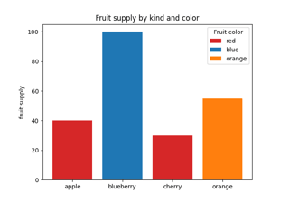

[Bar color demo](https://matplotlib.org/stable/gallery/lines_bars_and_markers/bar_colors.html#sphx-glr-gallery-lines-bars-and-markers-bar-colors-py)

Bar color demo

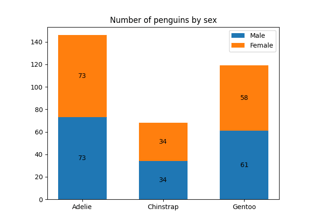

[Bar Label Demo](https://matplotlib.org/stable/gallery/lines_bars_and_markers/bar_label_demo.html#sphx-glr-gallery-lines-bars-and-markers-bar-label-demo-py)

Bar Label Demo

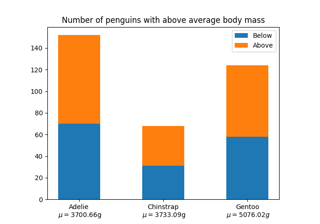

[Stacked bar chart](https://matplotlib.org/stable/gallery/lines_bars_and_markers/bar_stacked.html#sphx-glr-gallery-lines-bars-and-markers-bar-stacked-py)

Stacked bar chart

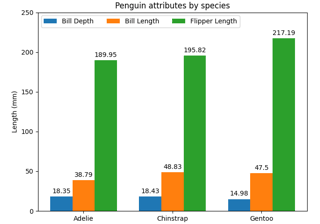

[Grouped bar chart with labels](https://matplotlib.org/stable/gallery/lines_bars_and_markers/barchart.html#sphx-glr-gallery-lines-bars-and-markers-barchart-py)

Grouped bar chart with labels

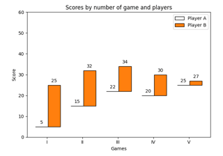

[Hat graph](https://matplotlib.org/stable/gallery/lines_bars_and_markers/hat_graph.html#sphx-glr-gallery-lines-bars-and-markers-hat-graph-py)

Hat graph

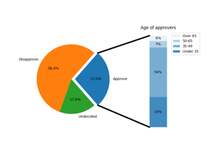

[Bar of pie](https://matplotlib.org/stable/gallery/pie_and_polar_charts/bar_of_pie.html#sphx-glr-gallery-pie-and-polar-charts-bar-of-pie-py)

Bar of pie

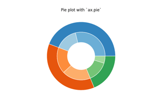

[Nested pie charts](https://matplotlib.org/stable/gallery/pie_and_polar_charts/nested_pie.html#sphx-glr-gallery-pie-and-polar-charts-nested-pie-py)

Nested pie charts

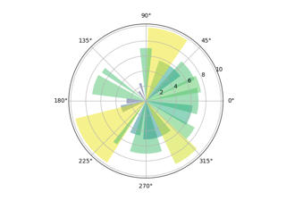

[Bar chart on polar axis](https://matplotlib.org/stable/gallery/pie_and_polar_charts/polar_bar.html#sphx-glr-gallery-pie-and-polar-charts-polar-bar-py)

Bar chart on polar axis

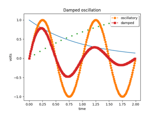

[Legend Demo](https://matplotlib.org/stable/gallery/text_labels_and_annotations/legend_demo.html#sphx-glr-gallery-text-labels-and-annotations-legend-demo-py)

Legend Demo

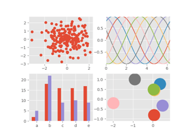

[ggplot style sheet](https://matplotlib.org/stable/gallery/style_sheets/ggplot.html#sphx-glr-gallery-style-sheets-ggplot-py)

ggplot style sheet

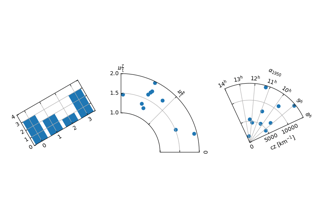

[floating_axes features](https://matplotlib.org/stable/gallery/axisartist/demo_floating_axes.html#sphx-glr-gallery-axisartist-demo-floating-axes-py)

``floating_axes`` features

[figure not shown]

[XKCD](https://matplotlib.org/stable/gallery/showcase/xkcd.html#sphx-glr-gallery-showcase-xkcd-py)

XKCD

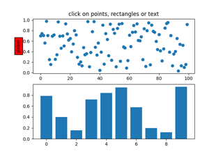

[Pick event demo](https://matplotlib.org/stable/gallery/event_handling/pick_event_demo.html#sphx-glr-gallery-event-handling-pick-event-demo-py)

Pick event demo

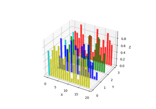

[Create 2D bar graphs in different planes](https://matplotlib.org/stable/gallery/mplot3d/bars3d.html#sphx-glr-gallery-mplot3d-bars3d-py)

Create 2D bar graphs in different planes

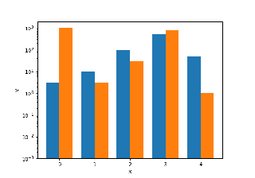

[Log Bar](https://matplotlib.org/stable/gallery/scales/log_bar.html#sphx-glr-gallery-scales-log-bar-py)

Log Bar

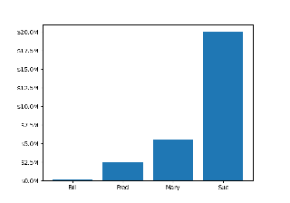

[Custom Ticker](https://matplotlib.org/stable/gallery/ticks/custom_ticker1.html#sphx-glr-gallery-ticks-custom-ticker1-py)

Custom Ticker

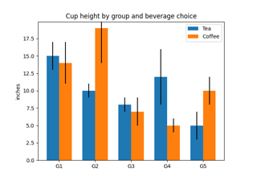

[Group barchart with units](https://matplotlib.org/stable/gallery/units/bar_unit_demo.html#sphx-glr-gallery-units-bar-unit-demo-py)

Group barchart with units

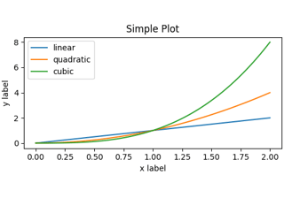

[Quick start guide](https://matplotlib.org/stable/tutorials/introductory/quick_start.html#sphx-glr-tutorials-introductory-quick-start-py)

Quick start guide

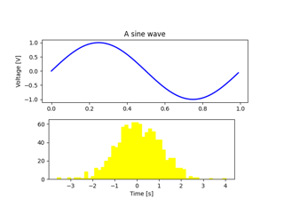

[Artist tutorial](https://matplotlib.org/stable/tutorials/intermediate/artists.html#sphx-glr-tutorials-intermediate-artists-py)

Artist tutorial

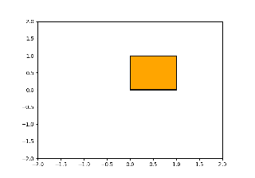

[Path Tutorial](https://matplotlib.org/stable/tutorials/advanced/path_tutorial.html#sphx-glr-tutorials-advanced-path-tutorial-py)

Path Tutorial

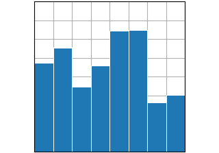

[bar(x, height)](https://matplotlib.org/stable/plot_types/basic/bar.html#sphx-glr-plot-types-basic-bar-py)

bar(x, height)

© 2012–2023 Matplotlib Development Team. All rights reserved.  
Licensed under the Matplotlib License Agreement.  
https://matplotlib.org/stable/api/_as_gen/matplotlib.axes.Axes.bar.html